# Analisis Variansi Dua Arah pada Dataset Diving

Sahda Huwaidah Estiningtyas

2024-04-21

# UTSSS

```r
data <- read.csv("C:/Users/LENOVO/OneDrive/Documents/UNY/Semester 2/Fish.csv", head = TRUE)
head(data)
```

```
##   Species Weight Length1 Length2 Length3  Height  Width
## 1   Bream    242    23.2    25.4    30.0 11.5200 4.0200
## 2   Bream    290    24.0    26.3    31.2 12.4800 4.3056
## 3   Bream    340    23.9    26.5    31.1 12.3778 4.6961
## 4   Bream    363    26.3    29.0    33.5 12.7300 4.4555
## 5   Bream    430    26.5    29.0    34.0 12.4440 5.1340
## 6   Bream    450    26.8    29.7    34.7 13.6024 4.9274
```

```r
model <- lm(Weight ~ Species + Length1 + Length2 + Length3 + Height + Width, data = data)
summary(model)
```

```
##
## Call:
## lm(formula = Weight ~ Species + Length1 + Length2 + Length3 +
##     Height + Width, data = data)
##
## Residuals:
##     Min      1Q  Median      3Q     Max
## -213.18  -53.19  -12.62   36.49  420.82
##
## Coefficients:
##                   Estimate Std. Error t value Pr(>|t|)
## (Intercept)      -918.3321   127.0831  -7.226  2.5e-11 ***
## SpeciesParkki     164.7227    75.6995   2.176 0.031152 *
## SpeciesPerch      137.9489   120.3135   1.147 0.253419
## SpeciesPike      -208.4294   135.3064  -1.540 0.125607
## SpeciesRoach      103.0400    91.3084   1.128 0.260954
## SpeciesSmelt      446.0733   119.4303   3.735 0.000268 ***
## SpeciesWhitefish   93.8742    96.6580   0.971 0.333045
## Length1           -80.3030    36.2785  -2.214 0.028403 *
## Length2            79.8886    45.7180   1.747 0.082653 .
## Length3            32.5354    29.3002   1.110 0.268633
## Height              5.2510    13.0560   0.402 0.688128
## Width              -0.5154    23.9130  -0.022 0.982832
## ---
## Signif. codes:  0 '***' 0.001 '**' 0.01 '*' 0.05 '.' 0.1 ' ' 1
##
## Residual standard error: 93.83 on 147 degrees of freedom
## Multiple R-squared:  0.9361, Adjusted R-squared:  0.9313
## F-statistic: 195.7 on 11 and 147 DF,  p-value: < 2.2e-16
```

```r
# Menghitung residu dari model
residuals <- resid(model)

# Melakukan uji normalitas Shapiro-Wilk
shapiro.test(residuals)
```

```
##
##  Shapiro-Wilk normality test
##
## data:  residuals
## W = 0.93335, p-value = 9.145e-07
```

```r
initial_model <- lm(Weight ~ 1, data = data)

# Menemukan model terbaik dengan metode seleksi forward dan kriteria BIC
forward_model <- step(initial_model, direction = "forward", kriteria = "BIC")
```

```
## Start:  AIC=1870.99
## Weight ~ 1
```

```r
# Melihat summary model
summary(forward_model)
```

```
##
## Call:
## lm(formula = Weight ~ 1, data = data)
##
## Residuals:
##    Min     1Q Median     3Q    Max
## -398.3 -278.3 -125.3  251.7 1251.7
##
## Coefficients:
##             Estimate Std. Error t value Pr(>|t|)
## (Intercept)   398.33      28.39   14.03   <2e-16 ***
## ---
## Signif. codes:  0 '***' 0.001 '**' 0.01 '*' 0.05 '.' 0.1 ' ' 1
##
## Residual standard error: 358 on 158 degrees of freedom
```

```r
step_model <- step(lm(Weight ~ Length1 + Length2 + Length3 + Height + Width, data = data), direction = "forward", k = log(nrow(data)), trace = FALSE)

# Melihat summary model
summary(step_model)
```

```
##
## Call:
## lm(formula = Weight ~ Length1 + Length2 + Length3 + Height +
##     Width, data = data)
##
## Residuals:
##     Min      1Q  Median      3Q     Max
## -243.69  -65.10  -25.52   57.98  447.25
##
## Coefficients:
##             Estimate Std. Error t value Pr(>|t|)
## (Intercept) -499.587     29.572 -16.894  < 2e-16 ***
## Length1       62.355     40.209   1.551  0.12302
## Length2       -6.527     41.759  -0.156  0.87601
## Length3      -29.026     17.353  -1.673  0.09643 .
## Height        28.297      8.729   3.242  0.00146 **
## Width         22.473     20.372   1.103  0.27169
## ---
## Signif. codes:  0 '***' 0.001 '**' 0.01 '*' 0.05 '.' 0.1 ' ' 1
##
## Residual standard error: 123.2 on 153 degrees of freedom
## Multiple R-squared:  0.8853, Adjusted R-squared:  0.8815
## F-statistic: 236.2 on 5 and 153 DF,  p-value: < 2.2e-16
```

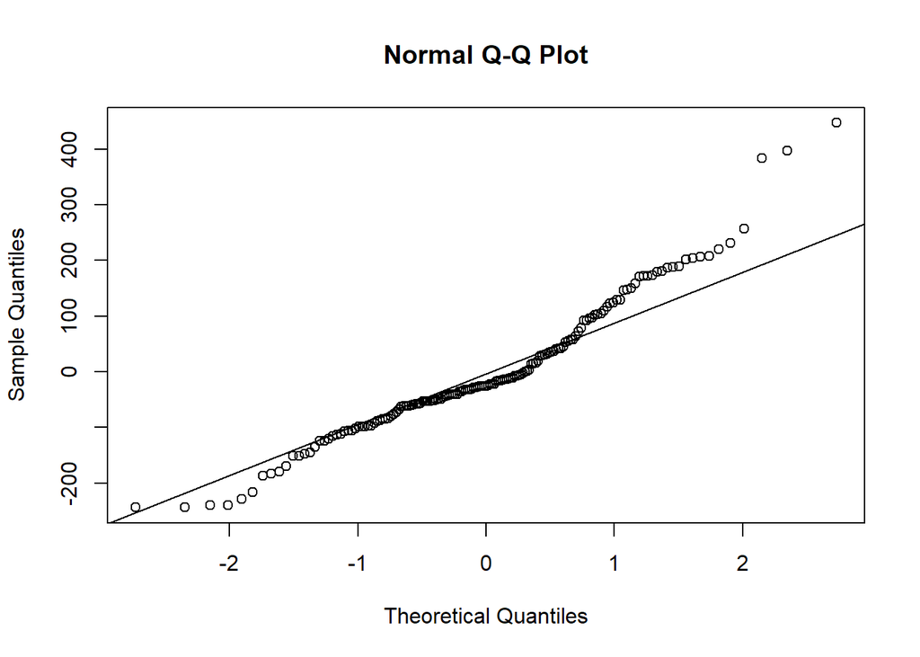

```r
# Melakukan regresi linier berganda
model <- lm(Weight ~ Length1 + Length2 + Length3 + Height + Width, data = data)

# Membuat plot Q-Q dari residu
qqnorm(resid(model))
qqline(resid(model))
```

```r
# Memuat data
data <- read.csv("C:/Users/LENOVO/OneDrive/Documents/UNY/Semester 2/twan.csv", head = TRUE)
head(data)
```

```
##       Day Adver Section
## 1  Monday    11    News
## 2  Monday     8    News
## 3  Monday     6    News
## 4  Monday     8    News
## 5 Tuesday     9    News
## 6 Tuesday    10    News
```

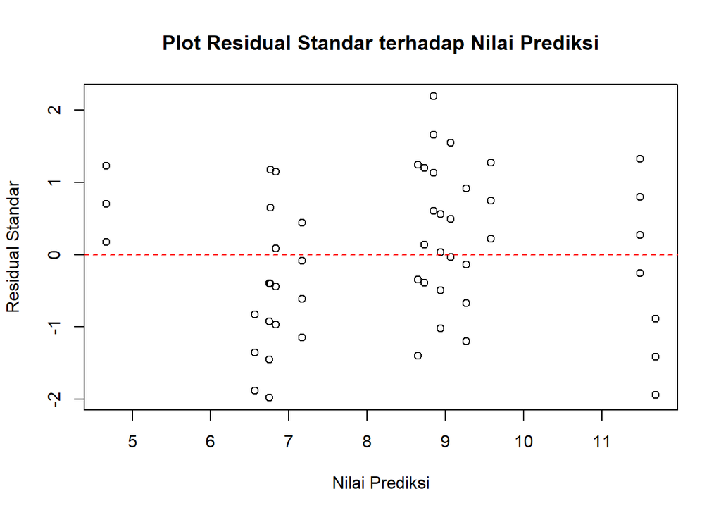

```r
# Membuat model regresi
model <- lm(Adver ~ Day + Section, data)

# Menghitung residual
residuals <- resid(model)

# Menghitung nilai prediksi
predicted <- predict(model)

# Menghitung residual standar
std_residuals <- rstandard(model)

# Membuat plot
plot(predicted, std_residuals, xlab = "Nilai Prediksi", ylab = "Residual Standar",
     main = "Plot Residual Standar terhadap Nilai Prediksi")

# Menambahkan garis horizontal di y = 0
abline(h = 0, col = "red", lty = 2)
```

```r
# Menghitung residual model
residuals <- resid(model)

# Uji normalitas menggunakan uji Shapiro-Wilk
shapiro.test(residuals)
```

```
##
##  Shapiro-Wilk normality test
##
## data:  residuals
## W = 0.97829, p-value = 0.3605
```

```r
# Melakukan analisis variansi
anova_result <- anova(model)

# Menampilkan hasil ANOVA
anova_result
```

```
## Analysis of Variance Table
##
## Response: Adver
##           Df  Sum Sq Mean Sq F value    Pr(>F)
## Day        4 146.833  36.708  9.0589 1.187e-05 ***
## Section    2  53.733  26.867  6.6301  0.002692 **
## Residuals 53 214.767   4.052
## ---
## Signif. codes:  0 '***' 0.001 '**' 0.01 '*' 0.05 '.' 0.1 ' ' 1
```

```r
tukey_result <- TukeyHSD(aov(model))
tukey_result
```

```
##   Tukey multiple comparisons of means
##     95% family-wise confidence level
##
## Fit: aov(formula = model)
##
## $Day
##                           diff        lwr         upr     p adj
## Monday-Friday      -2.83333333 -5.1540343 -0.51263240 0.0094385
## Thrusday-Friday    -4.91666667 -7.2373676 -2.59596574 0.0000019
## Tuesday-Friday     -2.41666667 -4.7373676 -0.09596574 0.0373566
## Wednesday-Friday   -2.75000000 -5.0707009 -0.42929907 0.0125928
## Thrusday-Monday    -2.08333333 -4.4040343  0.23736760 0.0981402
## Tuesday-Monday      0.41666667 -1.9040343  2.73736760 0.9863219
## Wednesday-Monday    0.08333333 -2.2373676  2.40403426 0.9999753
## Tuesday-Thrusday    2.50000000  0.1792991  4.82070093 0.0287660
## Wednesday-Thrusday  2.16666667 -0.1540343  4.48736760 0.0780657
## Wednesday-Tuesday  -0.33333333 -2.6540343  1.98736760 0.9941367
##
## $Section
##                 diff       lwr        upr     p adj
## News-Business   -0.2 -1.734936  1.3349362 0.9470957
## Sports-Business -2.1 -3.634936 -0.5650638 0.0048701
## Sports-News     -1.9 -3.434936 -0.3650638 0.0117434
```

The Genesis Diving Institute of Florida menyatakan penyelam scuba menggunakan berbagai sistem pendidikan yang berbeda. Organisasi ini telah mempelajari waktu yang dihabiskan di bawah air oleh penyelam scuba dalam menjelajahi gua dan perairan terbuka. Setiap penyelam juga diklasifikasikan berdasarkan kelompok umur. Penyelaman mandiri dipilih secara acak untuk setiap kombinasi kelompok umur dan tipe penyelaman. Data (dalam menit) diberikan dalam sebuah dataset.

Lakukan analisis variansi dua arah. Interpretasikan hasilnya. Gunakan 𝛼 = 0.001 untuk setiap pengujian hipotesis.

## Menyiapkan Dataset

```r
# Membaca data
diving <- read.csv("C:/Users/LENOVO/OneDrive/Documents/UNY/Semester 2/diving.csv", head = TRUE)
head(diving)
```

```
##   time dive.type age.group
## 1   39      cave     20-30
## 2   38      cave     20-30
## 3   41      cave     20-30
## 4   39      cave     20-30
## 5   41      cave     20-30
## 6   42      cave     20-30
```

```r
str(diving)
```

```
## 'data.frame':    64 obs. of  3 variables:
##  $ time     : int  39 38 41 39 41 42 40 40 42 40 ...
##  $ dive.type: chr  "cave" "cave" "cave" "cave" ...
##  $ age.group: chr  "20-30" "20-30" "20-30" "20-30" ...
```

```r
diving$int <- with(diving, interaction(age.group, dive.type), drop=TRUE)
head(diving$int)
```

```
## [1] 20-30.cave 20-30.cave 20-30.cave 20-30.cave 20-30.cave 20-30.cave
## 8 Levels: ≥ 50.cave 20-30.cave 30-40.cave 40-50.cave ... 40-50.open.water
```

```r
attach(diving)
```

#### Model Linear

$$y_{ijk} = \mu + \alpha_i + \beta_j +
(\alpha\beta)_{ij} + \epsilon_{ijk}$$

Dengan:

- $i = 1, 2, 3, 4$ mewakili kelompok umur (1: 20-30, 2: 30-40, 3: 40-50, 4: ≥50)
- $j = 1, 2$ mewakili tipe penyelaman (1: cave, 2: open water)
- $k = 1, 2, 3, 4, 5, 6, 7, 8$ mewakili penyelam $k$

Parameter model:

- $\mu$ adalah rata-rata waktu yang dihabiskan oleh penyelam secara keseluruhan.
- $\alpha_i$ adalah pengaruh kelompok umur ke-$i$.
- $\beta_j$ adalah pengaruh tipe penyelaman ke-$j$.
- $(\alpha\beta)_{ij}$ adalah pengaruh interaksi antara kelompok umur ke-$i$ dan tipe penyelaman ke-$j$.
- $\epsilon_{ijk}$ adalah galat dari interaksi kelompok umur dan tipe penyelam pada penyelam $k$.
- Asumsi: $\sum_{i=1}^{4} \alpha_i = 0$ , $\sum_{j=1}^{2} \beta_j = 0$ , $\sum_{i=1}^{4} \sum_{j=1}^{2} (\alpha\beta)_{ij} = 0$ , $\sum_{j=1}^{2} (\alpha\beta)_{ij} = 0$
- Galat percobaan diasumsikan independen serta $\epsilon_{ijk} \sim N(0, \sigma^2)$

Interpretasi hasil:

- Koefisien $\alpha_i$ menunjukkan perbedaan waktu yang dihabiskan di bawah air antara kelompok umur.
- Koefisien $\beta_j$ menunjukkan perbedaan waktu yang dihabiskan di bawah air antara tipe penyelaman.
- Interaksi $(\alpha\beta)_{ij}$ menunjukkan apakah efek kelompok umur berbeda antara tipe penyelaman.

## Plot Interaksi

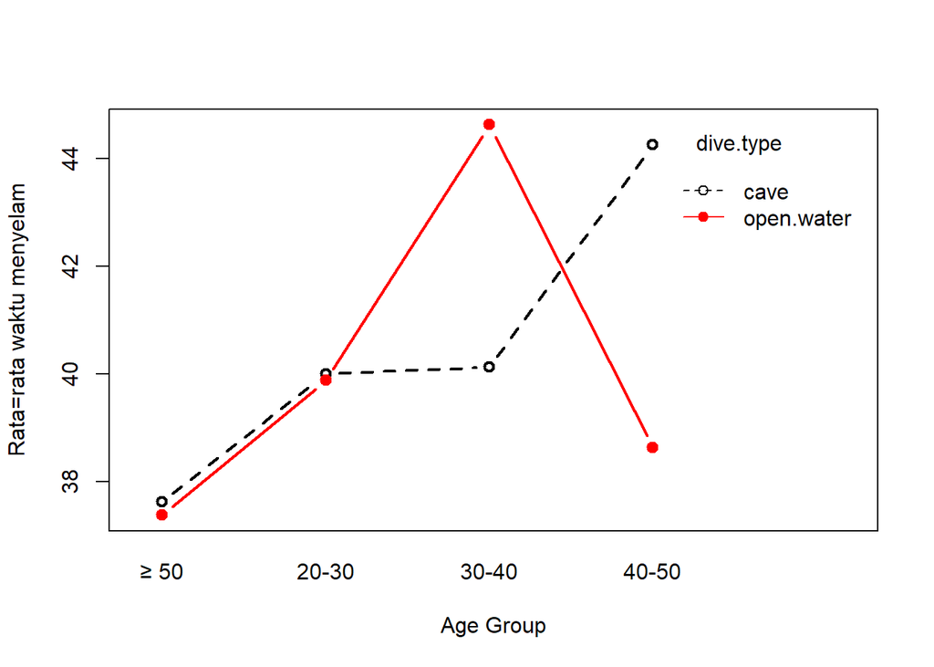

```r
interaction.plot(x.factor = age.group, trace.factor = dive.type, response = time, fun = mean,
                 type = "b", legend=TRUE, xlab="Age Group", ylab = "Rata=rata waktu menyelam",
                 pch = c(1,19), col = c("black", "red", "blue"), lwd=2)
```